# The Best and Worst Places to Remote Work

Sarah Curry

2024-12-23

# Where’s the Remote (Work)?

In this era of increasing interest in remote work, folks who are entering the job market or looking for a new position may aim to get hired at companies that are based in places where they can make a high income. In order to maximize their paycheck, they’re looking to live in places where they can rent or own housing where there is a low cost of living - so where should they look for a job and where should they live? Here are the Median Household Incomes in the 3 largest Metropolitan Statistical Areas per time zone in the United States.

```r
#https://geodata.bts.gov/datasets/usdot::time-zones/explore
timezone_us <- read_sf(dsn = "data/NTAD_Time_Zones_873827312334388986.geojson") %>%
  filter(zone == "Eastern" | zone == "Central" | zone == "Mountain" | zone == "Pacific") %>%
  st_transform(crs = 5070) %>%
  select(zone)

msa_mhi_22 <- get_acs(geography = "metropolitan statistical area/micropolitan statistical area",
                     year = 2022,
                     variables = c(pop = "B01003_001", mhi = "B19013_001", wfh = "B99087_005"),#median household income
                     geometry = TRUE,
                     output = "wide"
)

#match msa to time zone
msa_ctr <- msa_mhi_22 %>%
  st_transform(crs = 5070) %>%
  st_centroid()

msa_tz <- st_intersection(msa_ctr, timezone_us) %>%
  select(GEOID, zone) %>%
  st_drop_geometry()

#check on wfh pc
msa_mhi_22 <- msa_mhi_22 %>%
  mutate(pcentwfh = wfhE/popE)

#attach tz to each msa
msa_mhi_22 <- left_join(msa_mhi_22, msa_tz, by = "GEOID")

#average msa mhi per time zone
msa_mhi_22_avg <- msa_mhi_22 %>%
  group_by(zone) %>%
  summarize(mhiavg = mean(mhiE))

#grab top 3 per tz
msa_mhi_22_eastern <- msa_mhi_22 %>%
  filter(zone == "Eastern") %>%
  arrange(desc(popE)) %>%
  select(NAME, mhiE, zone) %>%
  rename("MSA" = "NAME", "MHI" = "mhiE") %>%
  head(3) %>%
  st_centroid()

msa_mhi_22_central <- msa_mhi_22 %>%
  filter(zone == "Central") %>%
  arrange(desc(popE)) %>%
  select(NAME, mhiE, zone) %>%
  rename("MSA" = "NAME", "MHI" = "mhiE") %>%
  head(3) %>%
  st_centroid()

msa_mhi_22_mountain <- msa_mhi_22 %>%
  filter(zone == "Mountain") %>%
  arrange(desc(popE)) %>%
  select(NAME, mhiE, zone) %>%
  rename("MSA" = "NAME", "MHI" = "mhiE") %>%
  head(3) %>%
  st_centroid()

msa_mhi_22_pacific <- msa_mhi_22 %>%
  filter(zone == "Pacific") %>%
  arrange(desc(popE)) %>%
  select(NAME, mhiE, zone) %>%
  rename("MSA" = "NAME", "MHI" = "mhiE") %>%
  head(3) %>%
  st_centroid()

msa_mhi_22 <- rbind(msa_mhi_22_eastern, msa_mhi_22_central)
msa_mhi_22 <- rbind(msa_mhi_22, msa_mhi_22_mountain)
msa_mhi_22 <- rbind(msa_mhi_22, msa_mhi_22_pacific)

#variables for each msa and mhi
chicagomhi <- 85087
dallasmhi <- 83398
houstonmhi <- 78061
newyorkmhi <- 93610
dcmhi <- 119803
philadelphiamhi <- 85555
phoenixmhi <- 79935
denvermhi <- 96920
saltlakecitymhi <- 90277
lamhi <- 89105
sanfranciscomhi <- 129315
riversidemhi <- 81041
```

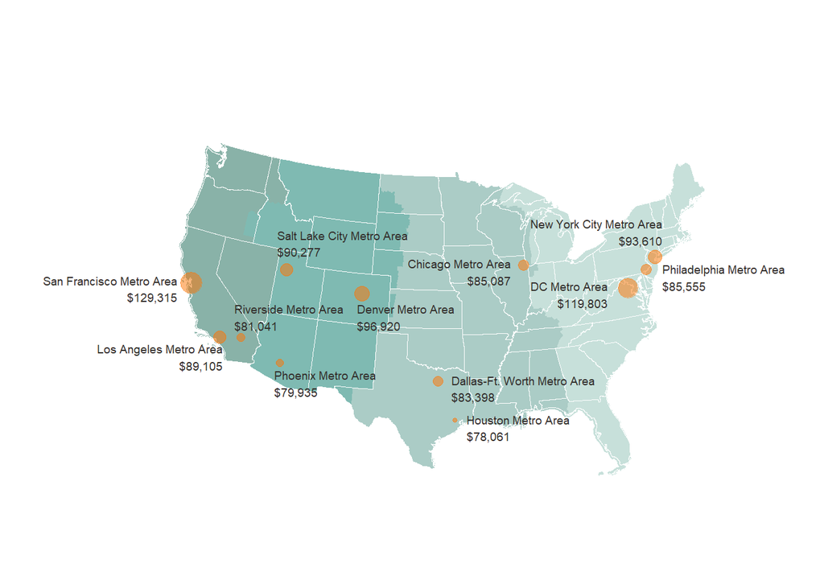

```r
ggplot() +
  geom_sf(data = timezone_us %>% filter(zone == "Eastern"), color = "transparent", fill = "#8FC1B5", alpha = 0.5) +
  geom_sf(data = timezone_us %>% filter(zone == "Central"), color = "transparent", fill = "#589A8D", alpha = 0.5) +
  geom_sf(data = timezone_us %>% filter(zone == "Mountain"), color = "transparent", fill = "#007566", alpha = 0.5) +
  geom_sf(data = timezone_us %>% filter(zone == "Pacific"), color = "transparent", fill = "#146551", alpha = 0.5) +
  geom_sf(data = us, color = "white", fill = "transparent", size = 2) +
  geom_sf(data = msa_mhi_22, color = "#FF7300", alpha  = 0.5, aes(size = MHI)) +
  annotate("text", x = 1880000, y = 2400000, label = "New York City Metro Area\n$93,610", color = "#332E2B", size = 2.5, hjust = 1) +
  annotate("text", x = 1880000, y = 2000000, label = "Philadelphia Metro Area\n$85,555", color = "#332E2B", size = 2.5, hjust = 0) +
  annotate("text", x = 1400000, y = 1850000, label = "DC Metro Area\n$119,803", color = "#332E2B", size = 2.5, hjust = 1) +
  annotate("text", x = 550000, y = 2050000, label = "Chicago Metro Area\n$85,087", color = "#332E2B", size = 2.5, hjust = 1) +
  annotate("text", x = 30000, y = 1022000, label = "Dallas-Ft. Worth Metro Area\n$83,398", color = "#332E2B", size = 2.5, hjust = 0) +
  annotate("text", x = 160000, y = 680000, label = "Houston Metro Area\n$78,061", color = "#332E2B", size = 2.5, hjust = 0) +
  annotate("text", x = -800000, y = 1650000, label = "Denver Metro Area\n$96,920", color = "#332E2B", size = 2.5, hjust = 0) +
  annotate("text", x = -1500000, y = 2300000, label = "Salt Lake City Metro Area\n$90,277", color = "#332E2B", size = 2.5, hjust = 0) +
  annotate("text", x = -1530000, y = 1070000, label = "Phoenix Metro Area\n$79,935", color = "#332E2B", size = 2.5, hjust = 0) +
  annotate("text", x = -1880000, y = 1650000, label = "Riverside Metro Area\n$81,041", color = "#332E2B", size = 2.5, hjust = 0) +
  annotate("text", x = -1980000, y = 1300000, label = "Los Angeles Metro Area\n$89,105", color = "#332E2B", size = 2.5, hjust = 1) +
  annotate("text", x = -2380000, y = 1900000, label = "San Francisco Metro Area\n$129,315", color = "#332E2B", size = 2.5, hjust = 1) +
  theme(legend.position = "none",
        panel.background = element_blank(),
        axis.text.x = element_blank(),
        axis.text.y = element_blank(),
        axis.ticks.x = element_blank(),
        axis.ticks.y = element_blank(),
        axis.line = element_blank(),
        axis.title.x = element_blank(),
        axis.title.y = element_blank(),
        axis.ticks = element_blank()) +
  xlim(-3500000, 2900000) +
  ylim(350000, 3400000)
```

Why look at the largest MSA’s? As more and more workplaces consider going back to work, the larger MSA’s are more likely to have a greater number of remote jobs available and are also likely to be the most urban and easy to get to in the event of a work schedule that requires going into the office from time to time. Let’s assume that remote employees would prefer to live and work in the same timezone for ease of completing assignments and attending meetings.

## Living Comfortably

The cost of living in a given region can be measured in various ways. MIT examines the summed monthly and annual budget that includes food, childcare, transportation, and housing costs. Another method to measure comfortability is by calculating if the monthly housing costs are less than 30% of a family’s household income.

> A cost-burdened household pays more than 30% of its income on rent and utilities.

### Methodology

For every county in each time zone, the annual living wage salary was calculated using the monthly costs for a rented or owned home - whichever was most affordable (a.k.a. “cheapest”).

## Eastern Region

If you work remotely out of New York City, DC, or Philadelphia, where in the Eastern time zone can you live comfortably?

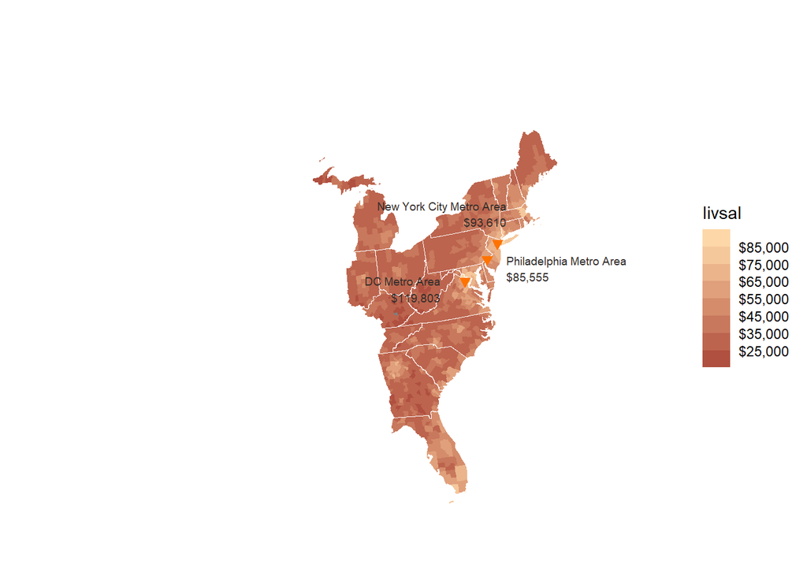

```r
ggplot() +
#  geom_sf(data = timezone_us %>% filter(zone == "Eastern"), color = "transparent", fill = "#8FC1B5", alpha = 0.5) +
  geom_sf(data = county_ls_22_eastern, aes(fill = livsal), color = "transparent") +
  scale_fill_steps(low = "#AA4639", high = "#FFDBAA", breaks = seq(15000, 90000, 10000), labels = scales::label_dollar()) +
  geom_sf(data = us, color = "white", fill = "transparent", size = 2) +
  geom_sf(data = msa_mhi_22 %>% filter(zone == "Eastern"), color = "#FF7300", fill = "#FF7300", size = 2, shape = 25) +
  annotate("text", x = 1880000, y = 2400000, label = "New York City Metro Area\n$93,610", color = "#332E2B", size = 2.5, hjust = 1) +
  annotate("text", x = 1880000, y = 2000000, label = "Philadelphia Metro Area\n$85,555", color = "#332E2B", size = 2.5, hjust = 0) +
  annotate("text", x = 1400000, y = 1850000, label = "DC Metro Area\n$119,803", color = "#332E2B", size = 2.5, hjust = 1) +
  theme(
#    legend.position = "none",
        panel.background = element_blank(),
        axis.text.x = element_blank(),
        axis.text.y = element_blank(),
        axis.ticks.x = element_blank(),
        axis.ticks.y = element_blank(),
        axis.line = element_blank(),
        axis.title.x = element_blank(),
        axis.title.y = element_blank(),
        axis.ticks = element_blank()
        ) +
  xlim(-1500000, 2900000) +
  ylim(350000, 3400000)
```

In the Northeastern region, the only area where a household would not be comfortable is in the DC/Northern Virginia area. Throughout most of Pennsylvania, a household would be more than comfortable given the cost of living and price of rents per County.

# Bike Rack